# Binary Classification: Scikit-Learn

## Introduction

#### Dataset:

- The dataset represents 10 years (1999-2008) of clinical care at 130 US hospitals and integrated delivery networks.
- It is an inpatient encounter (a hospital admission).
- It is a diabetic encounter, that is, one during which any kind of diabetes was entered to the system as a diagnosis.
- The length of stay was at least 1 day and at most 14 days.
- Laboratory tests were performed during the encounter.
- Medications were administered during the encounter.
- The data contains such attributes as patient number, race, gender, age, admission type, time in hospital, medical specialty of admitting physician, number of lab test performed, HbA1c test result, diagnosis, number of medication, diabetic medications, number of outpatient, inpatient, and emergency visits in the year before the hospitalization, etc.
- It contains 50 features (columns).
- It contains 74783 observations.
- Target variable: **change (No = 0, Ch = Yes = 1)**. Indicates if a person is detected with diabetes or not after diagnosed.
- Link to download dataset: **https://archive.ics.uci.edu/ml/machine-learning-databases/00296/**.

#### Libraries Used:

1. pandas
2. numpy
3. matplotlib
4. seaborn
5. IPython

#### Modules Used:

1. warnings
2. from IPython.display import IFrame
3. from sklearn.preprocessing import MinMaxScaler
4. from imblearn.over_sampling import SMOTE
5. from sklearn.cross_validation import train_test_split
6. from sklearn.feature_selection import RFE
7. from sklearn.metrics import confusion_matrix
8. from sklearn.metrics import classification_report
9. from sklearn.metrics import roc_auc_score
10. from sklearn.metrics import roc_curve
11. from sklearn.model_selection import StratifiedKFold
12. from sklearn.model_selection import cross_val_score
13. from sklearn.linear_model import LogisticRegression
14. from sklearn.tree import DecisionTreeClassifier
15. from sklearn.ensemble import RandomForestClassifier
16. from xgboost import XGBClassifier

#### Libraries to be installed before running the notebook:

1. **SMOTE**
   - *pip*: !pip install -U imbalanced-learn
   - *anaconda*: conda install -c glemaitre imbalanced-learn
2. **Seaborn**
   - *anaconda*: conda install -c anaconda seaborn
3. **XGBoost**
   - *pip*: !pip install xgboost

### Models created:

1. Logistic Regression
2. Decision Tree
3. Random Forest
4. XGBoost
5. Ensemble Learning.

### Approach:

- Fetched dataset.
- Imported required libraries.
- Checked variance of the data. No variables had less variance but two variables had very high variane,so removed them.
- Removed all the useless variables.
- Binned variable to reduce categorical levels.
- Label Encoded and One Hot Encoded variables.
- Scaled all the independent variables.
- Plotted heap map to see the correlation of the variables.
- Check the p-values of the variables after fitting with Logistic Regression.
- Fitted Logistic Regression model on all the remaining 27 variables.
- Reduced the variable count using Recursive Feature Elimination method and again fitted Logistic Regression Model.
- Fitted Decision Tree Model to check if other model is performing well.
- Fitted Random Forest model on all the 27 variables.
- Reduce the variable count using feature importance method and plotted each variable's importance.
- Fitted Random Forest Model on selected variables.
- Fitted XGBoost Model on selected variables with proper parameter tuning.
- Proceeded Ensemble Learning using Random Forest and KNN Classifier. Logistic Regression Model then created on the trained result.
- Checked the model performance using k(10)-fold-cross-validation.

## 1. Data Load

#### 1.1 Importing required libraries

```python
import warnings
warnings.simplefilter("ignore")

import pandas as pd
import numpy as np
import matplotlib.pyplot as plt
import seaborn as sns
from sklearn.cross_validation import train_test_split
```

#### 1.2 Importing dataset

```python
dataset = pd.read_csv('E:\ML\Classification\diabetic_data.csv')
```

#### 1.3 Inspecting total number of observations (rows) and variables (columns)

```python
dataset.shape
```

```
(74783, 50)
```

- We have 74,783 rows and 50 columns.

#### 1.5 Copying the instance of dataset into a new dataframe

```python
df = dataset
```

## 2. Data preprocessing

#### 2.1 Populating 10 rows of the dataset

```python
df.head(10)
```

|  | encounter_id | patient_nbr | race | gender | age | weight | admission_type_id | discharge_disposition_id | admission_source_id | time_in_hospital | ... | citoglipton | insulin | glyburide-metformin | glipizide-metformin | glimepiride-pioglitazone | metformin-rosiglitazone | metformin-pioglitazone | change | diabetesMed | readmitted |
| --- | --- | --- | --- | --- | --- | --- | --- | --- | --- | --- | --- | --- | --- | --- | --- | --- | --- | --- | --- | --- | --- |
| 0 | 2278392 | 8222157 | Caucasian | Female | [0-10) | ? | 6 | 25 | 1 | 1 | ... | No | No | No | No | No | No | No | No | No | NO |
| 1 | 149190 | 55629189 | Caucasian | Female | [10-20) | ? | 1 | 1 | 7 | 3 | ... | No | Up | No | No | No | No | No | Ch | Yes | >30 |
| 2 | 64410 | 86047875 | AfricanAmerican | Female | [20-30) | ? | 1 | 1 | 7 | 2 | ... | No | No | No | No | No | No | No | No | Yes | NO |
| 3 | 500364 | 82442376 | Caucasian | Male | [30-40) | ? | 1 | 1 | 7 | 2 | ... | No | Up | No | No | No | No | No | Ch | Yes | NO |
| 4 | 16680 | 42519267 | Caucasian | Male | [40-50) | ? | 1 | 1 | 7 | 1 | ... | No | Steady | No | No | No | No | No | Ch | Yes | NO |
| 5 | 35754 | 82637451 | Caucasian | Male | [50-60) | ? | 2 | 1 | 2 | 3 | ... | No | Steady | No | No | No | No | No | No | Yes | >30 |
| 6 | 55842 | 84259809 | Caucasian | Male | [60-70) | ? | 3 | 1 | 2 | 4 | ... | No | Steady | No | No | No | No | No | Ch | Yes | NO |
| 7 | 63768 | 114882984 | Caucasian | Male | [70-80) | ? | 1 | 1 | 7 | 5 | ... | No | No | No | No | No | No | No | No | Yes | >30 |
| 8 | 12522 | 48330783 | Caucasian | Female | [80-90) | ? | 2 | 1 | 4 | 13 | ... | No | Steady | No | No | No | No | No | Ch | Yes | NO |
| 9 | 15738 | 63555939 | Caucasian | Female | [90-100) | ? | 3 | 3 | 4 | 12 | ... | No | Steady | No | No | No | No | No | Ch | Yes | NO |

10 rows × 50 columns

#### 2.2 Inspecting datatype of all the variables

```python
df.info()
```

```
<class 'pandas.core.frame.DataFrame'>
RangeIndex: 74783 entries, 0 to 74782
Data columns (total 50 columns):
encounter_id                74783 non-null int64
patient_nbr                 74783 non-null int64
race                        74783 non-null object
gender                      74783 non-null object
age                         74783 non-null object
weight                      74783 non-null object
admission_type_id           74783 non-null int64
discharge_disposition_id    74783 non-null int64
admission_source_id         74783 non-null int64
time_in_hospital            74783 non-null int64
payer_code                  74783 non-null object
medical_specialty           74783 non-null object
num_lab_procedures          74783 non-null int64
num_procedures              74783 non-null int64
num_medications             74783 non-null int64
number_outpatient           74783 non-null int64
number_emergency            74783 non-null int64
number_inpatient            74783 non-null int64
diag_1                      74783 non-null object
diag_2                      74783 non-null object
diag_3                      74783 non-null object
number_diagnoses            74783 non-null int64
max_glu_serum               74783 non-null object
A1Cresult                   74783 non-null object
metformin                   74783 non-null object
repaglinide                 74783 non-null object
nateglinide                 74783 non-null object
chlorpropamide              74783 non-null object
glimepiride                 74783 non-null object
acetohexamide               74783 non-null object
glipizide                   74783 non-null object
glyburide                   74783 non-null object
tolbutamide                 74783 non-null object
pioglitazone                74783 non-null object
rosiglitazone               74783 non-null object
acarbose                    74783 non-null object
miglitol                    74782 non-null object
troglitazone                74782 non-null object
tolazamide                  74782 non-null object
examide                     74782 non-null object
citoglipton                 74782 non-null object
insulin                     74782 non-null object
glyburide-metformin         74782 non-null object
glipizide-metformin         74782 non-null object
glimepiride-pioglitazone    74782 non-null object
metformin-rosiglitazone     74782 non-null object
metformin-pioglitazone      74782 non-null object
change                      74782 non-null object
diabetesMed                 74782 non-null object
readmitted                  74782 non-null object
dtypes: int64(13), object(37)
memory usage: 28.5+ MB
```

#### 2.3 Inspecting Null values

```python
df.isna().sum()
```

```
encounter_id                0
patient_nbr                 0
race                        0
gender                      0
age                         0
weight                      0
admission_type_id           0
discharge_disposition_id    0
admission_source_id         0
time_in_hospital            0
payer_code                  0
medical_specialty           0
num_lab_procedures          0
num_procedures              0
num_medications             0
number_outpatient           0
number_emergency            0
number_inpatient            0
diag_1                      0
diag_2                      0
diag_3                      0
number_diagnoses            0
max_glu_serum               0
A1Cresult                   0
metformin                   0
repaglinide                 0
nateglinide                 0
chlorpropamide              0
glimepiride                 0
acetohexamide               0
glipizide                   0
glyburide                   0
tolbutamide                 0
pioglitazone                0
rosiglitazone               0
acarbose                    0
miglitol                    1
troglitazone                1
tolazamide                  1
examide                     1
citoglipton                 1
insulin                     1
glyburide-metformin         1
glipizide-metformin         1
glimepiride-pioglitazone    1
metformin-rosiglitazone     1
metformin-pioglitazone      1
change                      1
diabetesMed                 1
readmitted                  1
dtype: int64
```

#### 2.4 Descriptive statistics of numeric variables

```python
df.describe()
```

|  | encounter_id | patient_nbr | admission_type_id | discharge_disposition_id | admission_source_id | time_in_hospital | num_lab_procedures | num_procedures | num_medications | number_outpatient | number_emergency | number_inpatient | number_diagnoses |
| --- | --- | --- | --- | --- | --- | --- | --- | --- | --- | --- | --- | --- | --- |
| count | 7.478300e+04 | 7.478300e+04 | 74783.000000 | 74783.000000 | 74783.000000 | 74783.000000 | 74783.000000 | 74783.000000 | 74783.000000 | 74783.000000 | 74783.000000 | 74783.000000 | 74783.000000 |
| mean | 1.147189e+08 | 4.626453e+07 | 2.130805 | 3.959162 | 5.870960 | 4.478999 | 43.203295 | 1.339195 | 15.751508 | 0.316008 | 0.165198 | 0.622374 | 7.185149 |
| std | 5.707432e+07 | 3.571993e+07 | 1.530809 | 5.627624 | 4.364017 | 3.031166 | 19.070399 | 1.680880 | 8.161977 | 1.149866 | 0.720781 | 1.237404 | 1.983290 |
| min | 1.252200e+04 | 1.350000e+02 | 1.000000 | 1.000000 | 1.000000 | 1.000000 | 1.000000 | 0.000000 | 1.000000 | 0.000000 | 0.000000 | 0.000000 | 1.000000 |
| 25% | 6.732698e+07 | 1.732460e+07 | 1.000000 | 1.000000 | 1.000000 | 2.000000 | 32.000000 | 0.000000 | 10.000000 | 0.000000 | 0.000000 | 0.000000 | 6.000000 |
| 50% | 1.158277e+08 | 4.014178e+07 | 1.000000 | 1.000000 | 7.000000 | 4.000000 | 44.000000 | 1.000000 | 14.000000 | 0.000000 | 0.000000 | 0.000000 | 8.000000 |
| 75% | 1.613950e+08 | 8.285215e+07 | 3.000000 | 5.000000 | 7.000000 | 6.000000 | 56.000000 | 2.000000 | 20.000000 | 0.000000 | 0.000000 | 1.000000 | 9.000000 |
| max | 2.231281e+08 | 1.152185e+08 | 8.000000 | 28.000000 | 22.000000 | 14.000000 | 129.000000 | 6.000000 | 81.000000 | 42.000000 | 42.000000 | 21.000000 | 9.000000 |

#### 2.5 Checking variance of the data

```python
df.var()
```

```
encounter_id                3.257478e+15
patient_nbr                 1.275914e+15
admission_type_id           2.343378e+00
discharge_disposition_id    3.167015e+01
admission_source_id         1.904465e+01
time_in_hospital            9.187970e+00
num_lab_procedures          3.636801e+02
num_procedures              2.825359e+00
num_medications             6.661787e+01
number_outpatient           1.322191e+00
number_emergency            5.195253e-01
number_inpatient            1.531169e+00
number_diagnoses            3.933439e+00
dtype: float64
```

- Since, we are not getting any variable with low variance. So, we will keep all the variables for now. But we are observing high variance in some of the variables.

#### 2.6.1 Dropping variables "encounter_id","patient_nbr" as they have very high variance.

#### 2.6.2 Also dropping "diabetesMed" as it's the same as our dependent variable.

```python
df = df.drop(columns=['encounter_id','patient_nbr','diabetesMed'])
```

#### 2.7 Plotting distribution of dependent variable

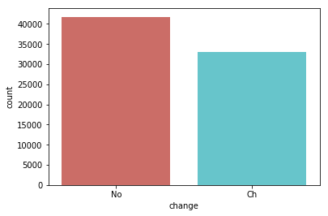

```
Percentage of No diabetes is 0.56
Percentage of diabetes is 0.44
```

```python
sns.countplot(x=df['change'],data=df,palette='hls')
plt.rcParams['figure.figsize'] = [10, 8]
plt.show()

#Checking percentage distribution of dependent variable
count_no_sub = len(df[df['change']=='No'])
count_sub = len(df[df['change']=='Ch'])
pct_of_no_sub = count_no_sub/(count_no_sub+count_sub)
print("Percentage of No diabetes is %0.2f"%pct_of_no_sub)
pct_of_sub = count_sub/(count_no_sub+count_sub)
print("Percentage of diabetes is %0.2f"%pct_of_sub)
```

#### 2.8 Plotting age vs diabetes frequency

```
Text(0,0.5,'Frequency of Diabetes')
```

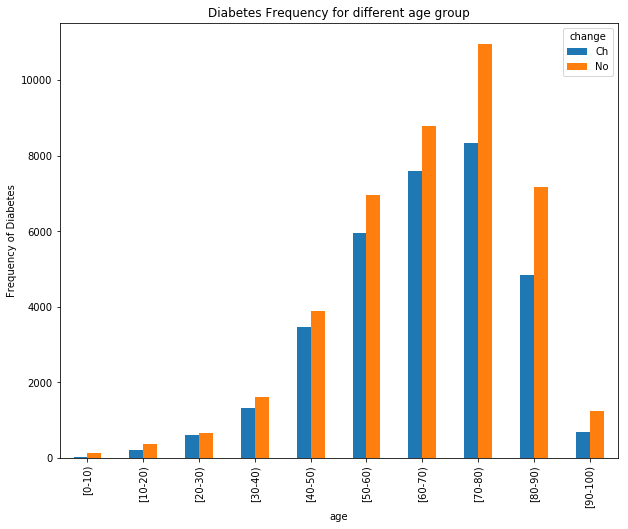

```python
%matplotlib inline
plt.rcParams['figure.figsize'] = [10, 8]
pd.crosstab(df.age,df.change).plot(kind='bar')
plt.title('Diabetes Frequency for different age group')
plt.xlabel('age')
plt.ylabel('Frequency of Diabetes')
```

#### 2.9 Plotting race vs diabetes frequency

```
Text(0,0.5,'Frequency of Diabetes')
```

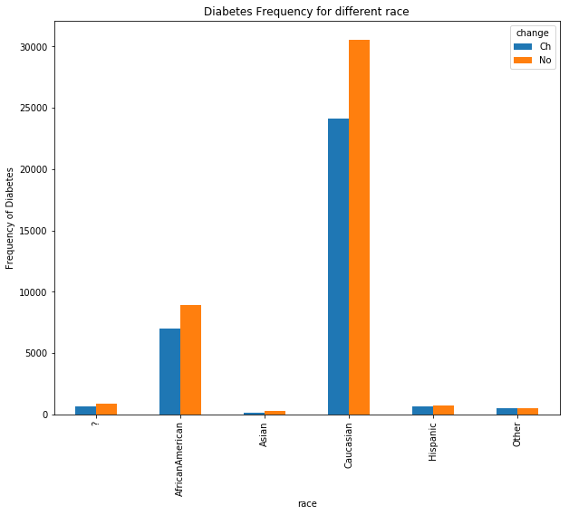

```python
%matplotlib inline
plt.rcParams['figure.figsize'] = [10, 8]
pd.crosstab(df.race,df.change).plot(kind='bar')
plt.title('Diabetes Frequency for different race')
plt.xlabel('race')
plt.ylabel('Frequency of Diabetes')
```

#### 2.10 Plotting gender vs diabetes frequency

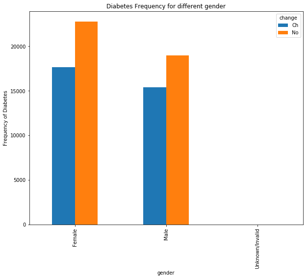

```python
%matplotlib inline
plt.rcParams['figure.figsize'] = [10, 8]
pd.crosstab(df.gender,df.change).plot(kind='bar')
plt.title('Diabetes Frequency for different gender')
plt.xlabel('gender')
plt.ylabel('Frequency of Diabetes')
plt.show()
```

#### 2.11 Plotting readmitted vs diabetes frequency

```
Text(0,0.5,'Frequency of Diabetes')
```

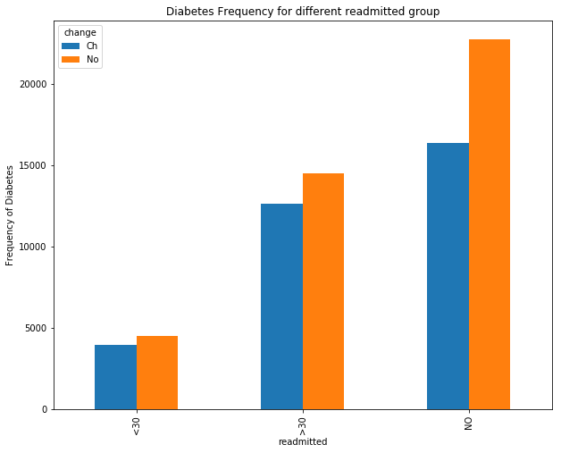

```python
%matplotlib inline
plt.rcParams['figure.figsize'] = [10, 8]
pd.crosstab(df.readmitted,df.change).plot(kind='bar')
plt.title('Diabetes Frequency for different readmitted group')
plt.xlabel('readmitted')
plt.ylabel('Frequency of Diabetes')
```